# Problem Set 3

Author

Aryan Singh

https://github.com/aryansinghmich/stats_506

```r
# environment set up
setwd("/Users/aryansingh/Desktop/stats_506_git/hw3")
pacman::p_load(tidyverse, haven, pscl, broom, knitr, DBI, RSQLite, microbenchmark, stringr)
```

# Problem 1

## Part A

```r
aux <- read_xpt("./cdc/AUX_I.xpt")
demo <- read_xpt("./cdc/DEMO_I.xpt")

cdc_data <- merge(aux, demo, by = "SEQN", all = FALSE)
dim(cdc_data)
```

```
[1] 4582  119
```

## Part B

```r
income_lbl <- c("$0 to $4,999", "$5,000 to $9,999", "$10,000 to $14,999", "$15,000 to $19,999",
    "$20,000 to $24,999", "$25,000 to $34,999", "$35,000 to $44,999", "$45,000 to $54,999",
    "$55,000 to $64,999", "$65,000 to $74,999", "$75,000 to $99,999", "$100,000 and Over")

cdc_data <- cdc_data %>% mutate(
    # gender
    RIAGENDR = factor(RIAGENDR, levels = 1:2, labels = c("Male", "Female")),
    # citizenship
    DMDCITZN = na_if(DMDCITZN, 9),
    DMDCITZN = na_if(DMDCITZN, 7),
    DMDCITZN = factor(DMDCITZN, levels = 1:2, labels = c("Citizen", "Not a U.S. Citizen")),
    # no. of children <5 yrs
    DMDHHSZA = factor(DMDHHSZA, levels = 0:3, labels = c("0","1","2","3 or more")),
    # annual income
    INDHHIN2 = na_if(INDHHIN2, 77),
    INDHHIN2 = na_if(INDHHIN2, 99),
    INDHHIN2 = na_if(INDHHIN2, 12), # $20,000 and Over -> NA
    INDHHIN2 = na_if(INDHHIN2, 13), # Under $20,000 -> NA
    INDHHIN2 = factor(INDHHIN2, levels = c(1:10, 14:15), labels = income_lbl),
    INDHHIN2 = fct_relevel(INDHHIN2, income_lbl)
)
```

I dropped “$20,000 and Over” and “Under $20,000” responses (codes 12 & 13) as NA to avoid overlapping categories and then put an ascending order on the remaining, non-overlapping income ranges. This ends up losing 438 annual household income entries.

## Part C

```r
# make rename variables and make continous
cdc_data <- cdc_data %>% mutate(
    kids_under5 = dplyr::recode(DMDHHSZA, "0"=0L, "1"=1L, "2"=2L, "3 or more"=3L, .default = NA_integer_),
    income_mid = dplyr::recode(INDHHIN2,
      "$0 to $4,999"=2500L, "$5,000 to $9,999"=7500L, "$10,000 to $14,999"=12500L,
      "$15,000 to $19,999"=17500L, "$20,000 to $24,999"=22500L, "$25,000 to $34,999"=30000L,
      "$35,000 to $44,999"=40000L, "$45,000 to $54,999"=50000L, "$55,000 to $64,999"=60000L,
      "$65,000 to $74,999"=70000L, "$75,000 to $99,999"=87500L, "$100,000 and Over"=125000L,
      .default = NA_integer_),
      gender  = droplevels(RIAGENDR),
      citizen = droplevels(DMDCITZN)
    )
```

```r
fit_pois <- function(df, resp, rhs, label){
  fml <- reformulate(rhs, response = resp)
  dat <- df %>% select(all_of(c(resp, rhs))) %>% na.omit()
  mod <- glm(fml, family = poisson(link="log"), data = dat)
  list(label = label, model = mod, n = nrow(dat),
    stats = tibble(Model = label, N = nrow(dat), `Pseudo_R^2` = unname(pscl::pR2(mod)["McFadden"]), AIC = AIC(mod)),
    coefs = broom::tidy(mod, conf.int = TRUE, exponentiate = TRUE) %>% filter(term != "(Intercept)") %>%
      transmute(Model = label, Term = term, IRR = estimate, CI_low = conf.low, CI_high = conf.high, p = p.value)
  )
}

mods <- list(
  fit_pois(cdc_data, "AUXTWIDR", c("gender"),
           label = "1R: right ear ~ gender"),
  fit_pois(cdc_data, "AUXTWIDR", c("gender","citizen","kids_under5","income_mid"),
           label = "2R: right ~ gender+citizenship+kids+income"),
  fit_pois(cdc_data, "AUXTWIDL", c("gender"),
           label = "1L: left ear ~ gender"),
  fit_pois(cdc_data, "AUXTWIDL", c("gender","citizen","kids_under5","income_mid"),
           label = "2L: left ~ gender+citizenship+kids+income")
)
```

```
fitting null model for pseudo-r2
fitting null model for pseudo-r2
fitting null model for pseudo-r2
fitting null model for pseudo-r2
```

```r
coef_tab  <- map_dfr(mods, "coefs") %>% mutate(
    Term = str_replace(Term, "^gender", "Gender: "),
    Term = str_replace(Term, "^citizen", "Citizen: "),
    Term = str_replace(Term, "^kids_under5$", "Children <=5 (count)"),
    Term = str_replace(Term, "^income_mid$", "Household income (midpoint)")
  ) %>% mutate(across(c(IRR, CI_low, CI_high, p), ~round(.x, 3)))

stats_tab <- map_dfr(mods, "stats") %>% mutate(across(c(`Pseudo_R^2`, AIC), ~round(.x, 3)))

kable(coef_tab, caption = "Incidence rate ratios (Poisson). IRR = exp(beta).")
```

Incidence rate ratios (Poisson). IRR = exp(beta).

| Model | Term | IRR | CI_low | CI_high | p |
| --- | --- | --- | --- | --- | --- |
| 1R: right ear ~ gender | Gender: Female | 1.009 | 1.003 | 1.016 | 0.006 |
| 2R: right ~ gender+citizenship+kids+income | Gender: Female | 1.015 | 1.008 | 1.022 | 0.000 |
| 2R: right ~ gender+citizenship+kids+income | Citizen: Not a U.S. Citizen | 1.046 | 1.036 | 1.055 | 0.000 |
| 2R: right ~ gender+citizenship+kids+income | Children <=5 (count) | 0.994 | 0.989 | 1.000 | 0.033 |
| 2R: right ~ gender+citizenship+kids+income | Household income (midpoint) | 1.000 | 1.000 | 1.000 | 0.000 |
| 1L: left ear ~ gender | Gender: Female | 1.013 | 1.006 | 1.020 | 0.000 |
| 2L: left ~ gender+citizenship+kids+income | Gender: Female | 1.019 | 1.012 | 1.026 | 0.000 |
| 2L: left ~ gender+citizenship+kids+income | Citizen: Not a U.S. Citizen | 1.022 | 1.013 | 1.031 | 0.000 |
| 2L: left ~ gender+citizenship+kids+income | Children <=5 (count) | 0.983 | 0.978 | 0.988 | 0.000 |
| 2L: left ~ gender+citizenship+kids+income | Household income (midpoint) | 1.000 | 1.000 | 1.000 | 0.000 |

```r
kable(stats_tab, caption = "Model sizes and fit stats.")
```

Model sizes and fit stats.

| Model | N | Pseudo_R^2 | AIC |
| --- | --- | --- | --- |
| 1R: right ear ~ gender | 4149 | 0.000 | 96618.48 |
| 2R: right ~ gender+citizenship+kids+income | 3705 | 0.005 | 84868.22 |
| 1L: left ear ~ gender | 4103 | 0.000 | 98685.15 |
| 2L: left ~ gender+citizenship+kids+income | 3665 | 0.002 | 86619.18 |

## Part D

```r
m2L <- mods[[4]]
summary(m2L$model)
```

```
Call:
glm(formula = fml, family = poisson(link = "log"), data = dat)

Coefficients:
                            Estimate Std. Error  z value Pr(>|z|)
(Intercept)                4.464e+00  4.089e-03 1091.626  < 2e-16 ***
genderFemale               1.877e-02  3.599e-03    5.215 1.84e-07 ***
citizenNot a U.S. Citizen  2.190e-02  4.648e-03    4.713 2.44e-06 ***
kids_under5               -1.716e-02  2.728e-03   -6.291 3.15e-10 ***
income_mid                -4.910e-07  4.564e-08  -10.759  < 2e-16 ***
---
Signif. codes:  0 '***' 0.001 '**' 0.01 '*' 0.05 '.' 0.1 ' ' 1

(Dispersion parameter for poisson family taken to be 1)

    Null deviance: 64149  on 3664  degrees of freedom
Residual deviance: 63937  on 3660  degrees of freedom
AIC: 86619

Number of Fisher Scoring iterations: 4
```

```r
coef(summary(m2L$model))["genderFemale", ] %>% kable()
```

|  | x |
| --- | --- |
| Estimate | 0.0187713 |
| Std. Error | 0.0035994 |
| z value | 5.2151680 |
| Pr(>\|z\|) | 0.0000002 |

```r
# summarize pop averages for context
cdc_summary <- cdc_data %>% summarise(
    mean_kids = mean(kids_under5, na.rm = TRUE),
    mean_income = mean(income_mid, na.rm = TRUE)
)

kable(cdc_summary)
```

| mean_kids | mean_income |
| --- | --- |
| 0.3417722 | 58633.47 |

```r
# build comparison dataset
newdat <- data.frame(
  gender = c("Male", "Female"),
  citizen = "Citizen",  # majority group
  kids_under5 = rep(cdc_summary$mean_kids, 2),
  income_mid = rep(cdc_summary$mean_income, 2)
)

# pred expect tymp width
preds <- predict(m2L$model, newdata = newdat, type = "response", se.fit = TRUE)

preds_df <- data.frame(
  gender = newdat$gender,
  predicted_width = preds$fit,
  lower_CI = preds$fit - 1.96 * preds$se.fit,
  upper_CI = preds$fit + 1.96 * preds$se.fit
)

kable(preds_df)
```

| gender | predicted_width | lower_CI | upper_CI |
| --- | --- | --- | --- |
| Male | 83.86134 | 83.40153 | 84.32114 |
| Female | 85.45039 | 85.01868 | 85.88209 |

In Model 2L, the coefficient for Gender (Female) was statistically significant (beta = 0.0188, SE = 0.0036, z = 5.22, p < 0.001). Exponentiating this coefficient yields an incidence rate ratio (IRR) of 1.019, indicating that, controlling for citizenship status, number of children under 5, and household income, females have approximately 1.9 % higher tympanometric width in the left ear compared to males.

The predicted mean tympanometric width for males was 83.86 (95 % CI 83.40 – 84.32) and for females 85.45 (95 % CI 85.02 – 85.88). Because the difference between these predicted means is consistent with the direction and significance of the IRR, there is strong statistical evidence that tympanometric width of the left ear differs by gender, with females exhibiting slightly larger widths on average.

# Problem 2

```r
sakila <- dbConnect(SQLite(), "sakila/sakila_master.db")
```

## Part A

```r
sql_a <- function() {
    dbGetQuery(sakila, "
        SELECT
            store_id,
            COUNT(*) AS n_customers,
            ROUND(100.0 * AVG(
                CASE
                WHEN active IN (1, '1', 'Y', 'y', 'T', 't') THEN 1
                ELSE 0
                END
            ), 2) AS pct_active
        FROM customer
        GROUP BY store_id
        ORDER BY store_id
    ")
}

kable(sql_a())
```

| store_id | n_customers | pct_active |
| --- | --- | --- |
| 1 | 326 | 97.55 |
| 2 | 273 | 97.44 |

```r
r_a <- function() {
    customer <- dbGetQuery(sakila, "SELECT store_id, active FROM customer")

    customer %>% mutate(active_num = as.integer(active == 1)) %>%
        group_by(store_id) %>% summarise(
            n_customers = n(),
            pct_active  = round(100 * mean(active_num, na.rm = TRUE), 2),
            .groups = "drop"
        ) %>% arrange(store_id)
}

kable(r_a())
```

| store_id | n_customers | pct_active |
| --- | --- | --- |
| 1 | 326 | 97.55 |
| 2 | 273 | 97.44 |

```r
microbenchmark(r_a(), sql_a(), times = 50L)
```

```
Unit: microseconds
    expr      min       lq      mean    median       uq      max neval cld
   r_a() 2196.124 2328.554 2653.1494 2456.1255 2723.630 5321.513    50  a
 sql_a()  210.945  235.955  315.7927  266.2335  324.474 1022.991    50   b
```

Each store has a similar number of customers (326 for Store 1 and 273 for Store 2) with about 97.5% of customers active for both. The SQL method was significantly faster than the R data-frame approach.

## Part B

```r
sql_b <- function() {
    dbGetQuery(sakila, "
        SELECT
            s.staff_id,
            s.first_name,
            s.last_name,
            co.country
        FROM staff AS s
        JOIN address AS a  ON s.address_id = a.address_id
        JOIN city    AS ci ON a.city_id = ci.city_id
        JOIN country AS co ON ci.country_id = co.country_id
        ORDER BY s.staff_id
    ")
}

kable(sql_b())
```

| staff_id | first_name | last_name | country |
| --- | --- | --- | --- |
| 1 | Mike | Hillyer | Canada |
| 2 | Jon | Stephens | Australia |

```r
r_b <- function() {
    staff <- dbGetQuery(sakila, "SELECT staff_id, first_name, last_name, address_id FROM staff")
    address <- dbGetQuery(sakila, "SELECT address_id, city_id FROM address")
    city <- dbGetQuery(sakila, "SELECT city_id, country_id FROM city")
    country <- dbGetQuery(sakila, "SELECT country_id, country FROM country")

    staff %>%
        left_join(address, by = "address_id") %>%
        left_join(city, by = "city_id") %>%
        left_join(country, by = "country_id") %>%
        select(staff_id, first_name, last_name, country) %>% arrange(staff_id)
}

kable(r_b())
```

| staff_id | first_name | last_name | country |
| --- | --- | --- | --- |
| 1 | Mike | Hillyer | Canada |
| 2 | Jon | Stephens | Australia |

```r
microbenchmark(r_b(), sql_b(), times = 50L)
```

```
Unit: microseconds
    expr      min       lq      mean   median       uq      max neval cld
   r_b() 3519.809 3780.118 4152.4874 3947.849 4234.972 8015.336    50  a
 sql_b()  129.601  146.780  219.6985  205.984  242.679  788.717    50   b
```

The SQL method was significantly faster than the R data-frame approach.

## Part C

```r
sql_c <- function() {
    dbGetQuery(sakila, "
        WITH film_revenue AS (
            SELECT
                f.film_id,
                f.title,
                SUM(p.amount) AS revenue
            FROM payment  AS p
            JOIN rental   AS r  ON p.rental_id   = r.rental_id
            JOIN inventory AS i ON r.inventory_id = i.inventory_id
            JOIN film     AS f  ON i.film_id      = f.film_id
            GROUP BY f.film_id, f.title
        )
        SELECT title, revenue
        FROM film_revenue
        WHERE revenue = (SELECT MAX(revenue) FROM film_revenue)
        ORDER BY title
    ")
}

kable(sql_c())
```

| title | revenue |
| --- | --- |
| TELEGRAPH VOYAGE | 231.73 |

```r
r_c <- function() {
    payment <- dbGetQuery(sakila, "SELECT rental_id, amount FROM payment")
    rental <- dbGetQuery(sakila, "SELECT rental_id, inventory_id FROM rental")
    inventory <- dbGetQuery(sakila, "SELECT inventory_id, film_id FROM inventory")
    film <- dbGetQuery(sakila, "SELECT film_id, title FROM film")

    payment %>%
        left_join(rental, by = "rental_id") %>%
        left_join(inventory, by = "inventory_id") %>%
        left_join(film, by = "film_id") %>%
        group_by(film_id, title) %>%
        summarise(revenue = sum(amount, na.rm = TRUE), .groups = "drop") %>%
        filter(revenue == max(revenue)) %>%
        arrange(title) %>%
        select(title, revenue)
}

kable(r_c())
```

| title | revenue |
| --- | --- |
| TELEGRAPH VOYAGE | 231.73 |

```r
microbenchmark(r_c(), sql_c(), times = 50L)
```

```
Unit: milliseconds
    expr      min       lq     mean   median       uq      max neval cld
   r_c() 18.90453 19.61239 20.60006 20.22721 21.08737 24.20578    50  a
 sql_c() 27.33150 28.09070 30.08110 28.79163 29.72910 54.78494    50   b
```

The film *TELEGRAPH VOYAGE* generated the highest total rental revenue. In this example, the R-based approach was slightly faster than the SQL query.

# Problem 3

```r
australia <- read_csv("./australia/au-500.csv")
```

## Part A

```r
australia %>% transmute(web = str_remove(web, "/+$")) %>%
    summarise(pct = mean(str_detect(web, regex("\\.com$", ignore_case = TRUE))) * 100) %>%
    pull(pct) %>% round(2)
```

```
[1] 0
```

```r
australia %>% transmute(
    ending = case_when(
      str_detect(web, regex("\\.com\\.au$", ignore_case = TRUE)) ~ ".com.au",
      str_detect(web, regex("\\.com$", ignore_case = TRUE)) ~ ".com",
      TRUE ~ "other"
    )) %>% count(ending, sort = TRUE) %>% kable()
```

| ending | n |
| --- | --- |
| .com.au | 500 |

0% of the websites end exactly in “.com”. All URLs included the ending “.com.au” instead.

## Part B

```r
australia %>% mutate(domain = str_extract(email, "(?<=@)[^@]+$")) %>%
    count(domain, sort = TRUE) %>% slice_max(n, n = 3) %>% kable()
```

| domain | n |
| --- | --- |
| hotmail.com | 114 |
| gmail.com | 102 |
| yahoo.com | 84 |

The most common email domain is hotmail.com (n = 114).

## Part C

```r
australia %>%
    mutate(
        non_alpha = str_detect(company_name, "[^A-Za-z,\\s]"),
        non_alpha_no_amp = str_detect(company_name, "[^A-Za-z,\\s&]")
    ) %>%
    summarise(
        pct_non_alpha = mean(non_alpha) * 100,
        pct_non_alpha_no_amp = mean(non_alpha_no_amp) * 100
    ) %>% mutate(across(everything(), \(x) round(x, 2))) %>%
    kable()
```

| pct_non_alpha | pct_non_alpha_no_amp |
| --- | --- |
| 9 | 0.8 |

About 9% of company names contain at least one non-alphabetic character (excluding commas and spaces). When ampersands (&) are also excluded, only 0.8% contain other non-alphabetic characters.

## Part D

```r
australia %>% mutate(
        # remove any non-digits, then reformat as 4-3-3
        phone1 = str_replace_all(phone1, "\\D", ""),
        phone2 = str_replace_all(phone2, "\\D", ""),
        phone1 = str_replace(phone1, "^(\\d{4})(\\d{3})(\\d{3})$", "\\1-\\2-\\3"),
        phone2 = str_replace(phone2, "^(\\d{4})(\\d{3})(\\d{3})$", "\\1-\\2-\\3")
    ) %>% select(phone1, phone2) %>% slice_head(n = 10) %>% kable()
```

| phone1 | phone2 |
| --- | --- |
| 0381-749-123 | 0458-665-290 |
| 0799-973-366 | 0497-622-620 |
| 0855-589-019 | 0427-885-282 |
| 0260-444-682 | 0443-795-912 |
| 0214-556-085 | 0453-666-885 |
| 0878-681-355 | 0451-966-921 |
| 0865-228-931 | 0427-991-688 |
| 0252-269-402 | 0415-961-606 |
| 0731-849-989 | 0411-732-965 |
| 0868-904-661 | 0461-862-457 |

## Part E

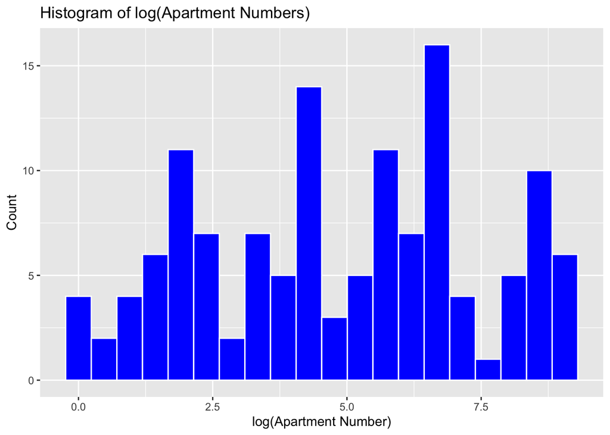

```r
apt_data <- australia %>% mutate(
        apt_num = str_extract(address, "(\\d+)$"),
        apt_num = as.numeric(apt_num)
    ) %>% filter(!is.na(apt_num), apt_num > 0)

ggplot(apt_data, aes(x = log(apt_num))) +
    geom_histogram(bins = 20, fill = "blue", color = "white") +
    labs(title = "Histogram of log(Apartment Numbers)",
        x = "log(Apartment Number)",
        y = "Count")
```

## Part F

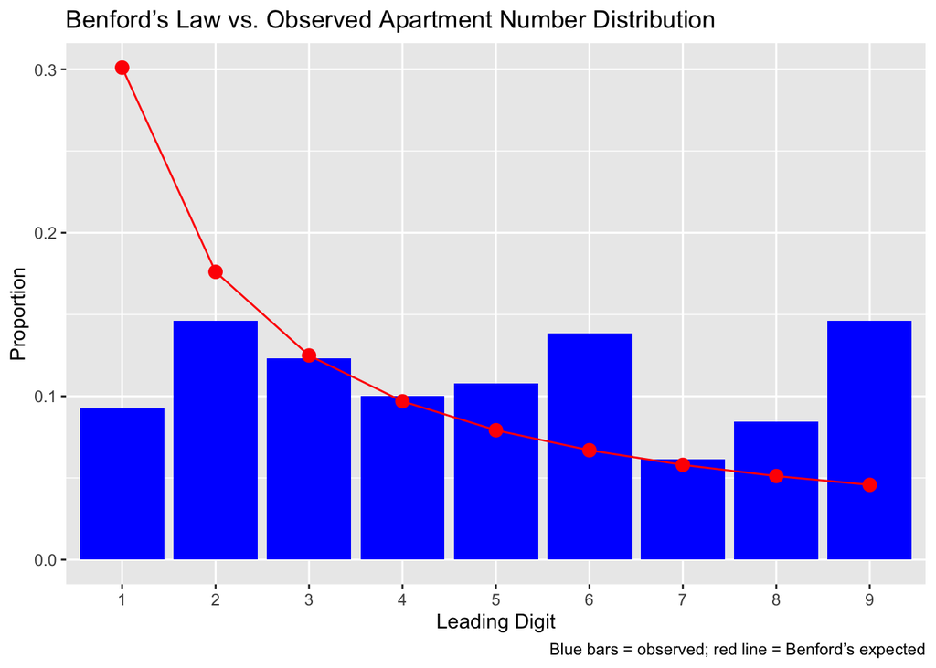

```r
benford_data <- apt_data %>%
  mutate(first_digit = as.numeric(str_sub(apt_num, 1, 1))) %>%
  count(first_digit) %>%
  mutate(
    prop = n / sum(n),
    benford = log10(1 + 1 / first_digit)
  )

# plot comparison
ggplot(benford_data, aes(x = factor(first_digit))) +
  geom_col(aes(y = prop), fill = "blue") +
  geom_point(aes(y = benford), color = "red", size = 3) +
  geom_line(aes(y = benford, group = 1), color = "red") +
  labs(
    title = "Benford’s Law vs. Observed Apartment Number Distribution",
    x = "Leading Digit",
    y = "Proportion",
    caption = "Blue bars = observed; red line = Benford’s expected"
  )
```

The leading digit frequencies of apartment numbers appear to deviate significantly from Benford’s Law. The observed distribution is roughly uniform rather than decreasing from 1 to 9. Thus, these apartment numbers would not pass as real world data.